# LongOmicsTraj: a GLUCOLD example

Nazanin Zounemat-Kermani

```r
library(LongOmicsTraj)
library(SummarizedExperiment)
library(MultiAssayExperiment)
library(S4Vectors)
library(dplyr)
library(tidyr)
library(tibble)
library(ggplot2)
library(scales)

knitr::opts_chunk$set(
  collapse = TRUE,
  comment = "#>",
  fig.align = "center",
  message = FALSE,
  warning = FALSE
)
```

## Overview

LongOmicsTraj converts repeated molecular measurements into discrete longitudinal trajectory labels.

This example uses a selected GLUCOLD transcriptomic dataset containing 71 genes measured across 221 longitudinal samples at Baseline, 6 Months and 30 Months.

The workflow is:

```
Expression matrix + clinical metadata
                ↓
        LongOmicsTraj object
                ↓
       Estimate trajectories
                ↓
     Compute adjacent changes
                ↓
        Map changes to OTS
                ↓
       Query and visualise
```

## Load the GLUCOLD data

The package includes two objects:

- an expression matrix;
- a clinical metadata table.

```r
# Load the example GLUCOLD expression matrix included with the package.
# The demo contains 71 selected genes measured across 221 longitudinal samples.
# The reduced feature set keeps the example fast to run.
data(
  "lot_glucold_expression",
  package = "LongOmicsTraj"
)

# Load the matching clinical metadata.
# There is one metadata row for each expression-matrix sample.
#
# Required columns:
#   sample_id  = unique sample identifier; must match colnames(expr_use)
#   subject_id = participant identifier; repeated across longitudinal visits
#   visit      = visit label, for example Baseline, 6 Months, 30 Months
#   group      = treatment or clinical group
#
# A numeric time column may also be added later for models such as GAM:
#   time       = numerical visit time, for example 0, 6, 30
data(
  "lot_glucold_clinical",
  package = "LongOmicsTraj"
)

# Replace these two objects with your own data.
#
# Expression matrix:
#   rows    = genes or molecular features
#   columns = samples
expr_use <- lot_glucold_expression

# Clinical metadata:
#   rows = samples
#   required columns = sample_id, subject_id, visit, group
#   sample_id values must match the expression-matrix column names
meta_use <- lot_glucold_clinical
```

Rows are genes and columns are samples.

```r
dim(expr_use)
```

```
#> [1]  71 221
```

```r
expr_use[1:5, 1:5]
```

```
#>        GSM883944 GSM883945 GSM883946 GSM883947 GSM883948
#> ATP2A3  5.192163  6.380106  6.577776  6.476847  7.101043
#> CAT     5.923509  7.669481  6.749482  7.565173  7.622587
#> CCL24   3.508556  3.551733  4.088679  3.479406  3.416885
#> CCL26   3.237542  2.702321  3.492727  2.623864  2.967484
#> CCL3    4.990029  4.475904  5.198765  4.551517  5.196277
```

The metadata contain one row per sample.

```r
dim(meta_use)
```

```
#> [1] 221   4
```

```r
head(meta_use)
```

```
#>           sample_id subject_id     visit         group
#> GSM883944 GSM883944       1076  Baseline       Placebo
#> GSM883945 GSM883945       1076 30 Months       Placebo
#> GSM883946 GSM883946       1092  Baseline ICS 30 months
#> GSM883947 GSM883947       1092 30 Months ICS 30 months
#> GSM883948 GSM883948       2017  Baseline ICS 30 months
#> GSM883949 GSM883949       2017 30 Months ICS 30 months
```

The required metadata columns are:

```r
colnames(meta_use)
```

```
#> [1] "sample_id"  "subject_id" "visit"      "group"
```

Users analysing their own data only need to replace:

```r
expr_use <- your_expression_matrix
meta_use <- your_clinical_metadata
```

The expression matrix should have genes in rows and samples in columns. The metadata should contain `sample_id`, `subject_id`, `visit` and `group`.

## Check and align the samples

```r
expr_use <- as.matrix(expr_use)
storage.mode(expr_use) <- "numeric"

meta_use <- as.data.frame(meta_use)

required_columns <- c(
  "sample_id",
  "subject_id",
  "visit",
  "group"
)

missing_columns <- setdiff(
  required_columns,
  colnames(meta_use)
)

if (length(missing_columns) > 0L) {
  stop(
    "Clinical metadata are missing: ",
    paste(missing_columns, collapse = ", ")
  )
}

if (is.null(colnames(expr_use))) {
  stop(
    "The expression matrix must have sample IDs as column names."
  )
}

if (!setequal(
  colnames(expr_use),
  meta_use$sample_id
)) {
  stop(
    "Expression sample names do not match metadata sample IDs."
  )
}

meta_use <- meta_use[
  match(
    colnames(expr_use),
    meta_use$sample_id
  ),
  ,
  drop = FALSE
]

rownames(meta_use) <- meta_use$sample_id

stopifnot(
  identical(
    colnames(expr_use),
    meta_use$sample_id
  )
)
```

## Define the visit order

```r
clinical_visits <- c(
  "Baseline",
  "6 Months",
  "30 Months"
)

meta_use$visit <- factor(
  meta_use$visit,
  levels = clinical_visits,
  ordered = TRUE
)

time_lookup <- c(
  "Baseline" = 0,
  "6 Months" = 6,
  "30 Months" = 30
)

meta_use$time <- unname(
  time_lookup[
    as.character(meta_use$visit)
  ]
)

if (anyNA(meta_use$time)) {
  stop(
    "One or more visit labels could not be converted to time."
  )
}

table(meta_use$visit)
```

```
#>
#>  Baseline  6 Months 30 Months
#>        79        77        65
```

```r
table(meta_use$group)
```

```
#>
#>                ICS 30 months ICS 6 months then withdrawal           ICS/LABA 30 months
#>                           61                           59                           46
#>                      Placebo
#>                           55
```

## Create the LongOmicsTraj object

First combine the expression matrix and metadata in a `SummarizedExperiment`.

```r
se <- SummarizedExperiment::SummarizedExperiment(
  assays = list(
    transcriptomics = expr_use
  ),
  colData = S4Vectors::DataFrame(
    meta_use,
    row.names = meta_use$sample_id
  )
)

se
```

```
#> class: SummarizedExperiment
#> dim: 71 221
#> metadata(0):
#> assays(1): transcriptomics
#> rownames(71): ATP2A3 CAT ... XBP1 ZBTB16
#> rowData names(0):
#> colnames(221): GSM883944 GSM883945 ... GSM884163 GSM884164
#> colData names(5): sample_id subject_id visit group time
```

Place the assay in a `MultiAssayExperiment`.

```r
mae <- MultiAssayExperiment::MultiAssayExperiment(
  experiments =
    MultiAssayExperiment::ExperimentList(
      transcriptomics = se
    )
)

mae
```

```
#> A MultiAssayExperiment object of 1 listed
#>  experiment with a user-defined name and respective class.
#>  Containing an ExperimentList class object of length 1:
#>  [1] transcriptomics: SummarizedExperiment with 71 rows and 221 columns
#> Functionality:
#>  experiments() - obtain the ExperimentList instance
#>  colData() - the primary/phenotype DataFrame
#>  sampleMap() - the sample coordination DataFrame
#>  `$`, `[`, `[[` - extract colData columns, subset, or experiment
#>  *Format() - convert into a long or wide DataFrame
#>  assays() - convert ExperimentList to a SimpleList of matrices
#>  exportClass() - save data to flat files
```

Create the analysis object.

```r
lot_object <- methods::new(
  "LongOmicsTraj",
  mae = mae
)

methods::validObject(lot_object)
```

```
#> [1] TRUE
```

```r
lot_object
```

```
#> LongOmicsTraj object
#> -------------------
#> Assays:          1
#> VMM rows:        0
#> Delta rows:      0
#> Threshold rows:  0
#> OTS rows:        0
#> Relationships:   0
#> Results:         0
```

A value of `TRUE` confirms that the object is valid.

## Empirical trajectory estimation

The empirical estimator calculates visit-level summaries directly from the observed data.

```r
lot_emp <- lot_from_empirical(
  object = lot_object,
  assay = "transcriptomics",
  visits = clinical_visits,
  overwrite = TRUE
)

lot_emp <- lot_compute_deltas(
  object = lot_emp,
  assay = "transcriptomics",
  visits = clinical_visits,
  overwrite = TRUE
)

lot_emp <- lot_compute_thresholds(
  object = lot_emp,
  assay = "transcriptomics",
  method = "hybrid",
  delta_min = 0.15,
  k = 0.5,
  visits = clinical_visits,
  overwrite = TRUE
)

lot_emp <- lot_map_to_ots(
  object = lot_emp,
  visits = clinical_visits,
  overwrite = TRUE
)

head(
  as.data.frame(lot_emp@ots)
)
```

```
#>   object_id object_type           assay                        group estimator topology_label n_transitions
#> 1    ATP2A3        gene transcriptomics                ICS 30 months empirical      flat_down             2
#> 2    ATP2A3        gene transcriptomics ICS 6 months then withdrawal empirical      flat_flat             2
#> 3    ATP2A3        gene transcriptomics           ICS/LABA 30 months empirical        down_up             2
#> 4    ATP2A3        gene transcriptomics                      Placebo empirical      flat_down             2
#> 5       CAT        gene transcriptomics                ICS 30 months empirical      flat_flat             2
#> 6       CAT        gene transcriptomics ICS 6 months then withdrawal empirical      flat_down             2
```

Each gene is assigned an Omics Trajectory Signature such as:

- `flat_flat`: stable;
- `up_up`: sustained increase;
- `down_down`: sustained decrease;
- `up_down`: transient increase;
- `down_up`: rebound.

## maSigPro trajectory estimation

Here we also fit polynomial trajectories using the maSigPro estimator.

```r
lot_mas <- lot_from_masigpro(
  object = lot_object,
  assay = "transcriptomics",
  visits = clinical_visits,
  overwrite = TRUE
)

lot_mas <- lot_compute_deltas(
  object = lot_mas,
  assay = "transcriptomics",
  visits = clinical_visits,
  overwrite = TRUE
)

lot_mas <- lot_compute_thresholds(
  object = lot_mas,
  assay = "transcriptomics",
  method = "hybrid",
  delta_min = 0.15,
  k = 0.5,
  visits = clinical_visits,
  overwrite = TRUE
)

lot_mas <- lot_map_to_ots(
  object = lot_mas,
  visits = clinical_visits,
  overwrite = TRUE
)

head(
  as.data.frame(lot_mas@ots)
)
```

```
#>   object_id object_type           assay                        group estimator topology_label n_transitions
#> 1    ATP2A3        gene transcriptomics                ICS 30 months  masigpro      flat_down             2
#> 2    ATP2A3        gene transcriptomics ICS 6 months then withdrawal  masigpro      flat_flat             2
#> 3    ATP2A3        gene transcriptomics           ICS/LABA 30 months  masigpro        down_up             2
#> 4    ATP2A3        gene transcriptomics                      Placebo  masigpro      flat_down             2
#> 5       CAT        gene transcriptomics                ICS 30 months  masigpro      flat_flat             2
#> 6       CAT        gene transcriptomics ICS 6 months then withdrawal  masigpro      flat_down             2
```

## OTS distribution

The first summary shows how trajectory labels are distributed across treatment groups.

```r
ots_results <- as.data.frame(
  lot_mas@ots
) |>
  dplyr::filter(
    estimator == "masigpro",
    !is.na(group),
    !is.na(topology_label)
  )

ots_distribution <- ots_results |>
  dplyr::count(
    group,
    topology_label,
    name = "n"
  ) |>
  dplyr::group_by(group) |>
  dplyr::mutate(
    proportion = n / sum(n)
  ) |>
  dplyr::ungroup()
```

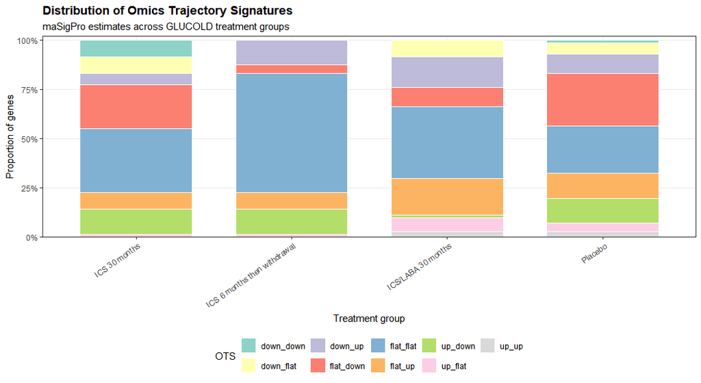

```r
p_ots_distribution <- ggplot2::ggplot(
  ots_distribution,
  ggplot2::aes(
    x = group,
    y = proportion,
    fill = topology_label
  )
) +
  ggplot2::geom_col(
    width = 0.72,
    colour = "white",
    linewidth = 0.25
  ) +
  ggplot2::scale_y_continuous(
    labels = scales::percent_format(),
    expand = ggplot2::expansion(
      mult = c(0, 0.02)
    )
  ) +
  ggplot2::scale_fill_brewer(
    palette = "Set3",
    name = "OTS"
  ) +
  ggplot2::labs(
    title = "Distribution of Omics Trajectory Signatures",
    subtitle = "maSigPro estimates across GLUCOLD treatment groups",
    x = "Treatment group",
    y = "Proportion of genes"
  ) +
  ggplot2::theme_bw(base_size = 11) +
  ggplot2::theme(
    plot.title = ggplot2::element_text(
      face = "bold"
    ),
    axis.text.x = ggplot2::element_text(
      angle = 35,
      hjust = 1
    ),
    panel.grid.minor = ggplot2::element_blank(),
    legend.position = "bottom"
  )

p_ots_distribution
```

The figure provides a compact comparison of longitudinal response patterns across treatment groups.

## Query treatment-specific trajectories

The next query searches for genes that:

- show a transient or rebound trajectory after ICS withdrawal;
- show sustained or partially sustained change during continuous ICS treatment;
- do not show a transient or rebound pattern under placebo.

```r
withdrawal_specific <- lot_query(
  lot_mas,
  estimator = "masigpro",
  conditions = list(
    "ICS 6 months then withdrawal" = c(
      "up_down",
      "down_up"
    ),
    "ICS 30 months" = c(
      "up_up",
      "up_flat",
      "down_down",
      "down_flat"
    ),
    "Placebo" = NOT(
      c(
        "up_down",
        "down_up"
      )
    )
  )
)

withdrawal_specific <- as.data.frame(
  withdrawal_specific
)

head(withdrawal_specific)
```

```
#>   object_id object_type           assay                        group estimator topology_label n_transitions
#> 1      CCL5        gene transcriptomics                ICS 30 months  masigpro      down_down             2
#> 2      CCL5        gene transcriptomics ICS 6 months then withdrawal  masigpro        down_up             2
#> 3      CCL5        gene transcriptomics           ICS/LABA 30 months  masigpro      down_flat             2
#> 4      CCL5        gene transcriptomics                      Placebo  masigpro      flat_flat             2
#> 5     CD79A        gene transcriptomics                ICS 30 months  masigpro      down_down             2
#> 6     CD79A        gene transcriptomics ICS 6 months then withdrawal  masigpro        down_up             2
```

## Query result summary

```r
query_distribution <- withdrawal_specific |>
  dplyr::count(
    group,
    topology_label,
    name = "n"
  )
```

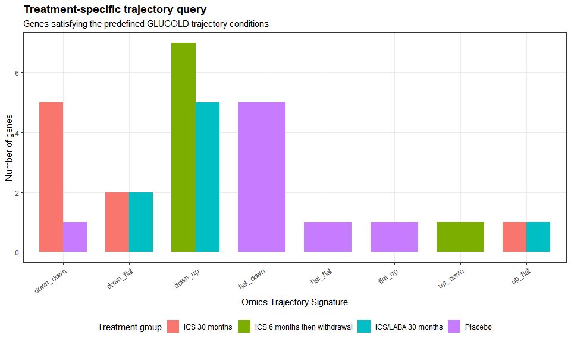

```r
p_query <- ggplot2::ggplot(
  query_distribution,
  ggplot2::aes(
    x = topology_label,
    y = n,
    fill = group
  )
) +
  ggplot2::geom_col(
    position = "dodge",
    width = 0.72
  ) +
  ggplot2::labs(
    title = "Treatment-specific trajectory query",
    subtitle = "Genes satisfying the predefined GLUCOLD trajectory conditions",
    x = "Omics Trajectory Signature",
    y = "Number of genes",
    fill = "Treatment group"
  ) +
  ggplot2::theme_bw(base_size = 11) +
  ggplot2::theme(
    plot.title = ggplot2::element_text(
      face = "bold"
    ),
    axis.text.x = ggplot2::element_text(
      angle = 35,
      hjust = 1
    ),
    panel.grid.minor = ggplot2::element_blank(),
    legend.position = "bottom"
  )

p_query
```

## Representative genes

Select genes representing different OTS classes where possible.

```r
example_genes <- withdrawal_specific |>
  dplyr::distinct(
    object_id,
    topology_label
  ) |>
  dplyr::group_by(topology_label) |>
  dplyr::slice_head(n = 1) |>
  dplyr::ungroup() |>
  dplyr::slice_head(n = 6) |>
  dplyr::pull(object_id) |>
  unique()

example_genes <- intersect(
  example_genes,
  rownames(expr_use)
)

if (length(example_genes) == 0L) {
  stop(
    "No query-selected genes were found in the expression matrix."
  )
}

example_genes
```

```
#> [1] "CCL5"   "COL1A1" "IL1RL1"
```

## Prepare expression profiles

```r
expr <- expr_use
clinical_data <- meta_use

expression_long <- as.data.frame(
  expr[
    example_genes,
    ,
    drop = FALSE
  ]
) |>
  tibble::rownames_to_column(
    "gene"
  ) |>
  tidyr::pivot_longer(
    cols = -gene,
    names_to = "sample_id",
    values_to = "expression"
  ) |>
  dplyr::left_join(
    clinical_data |>
      dplyr::select(
        sample_id,
        subject_id,
        visit,
        group
      ),
    by = "sample_id"
  )

selected_groups <- c(
  "ICS 30 months",
  "ICS 6 months then withdrawal",
  "Placebo"
)

expression_long <- expression_long |>
  dplyr::filter(
    group %in% selected_groups
  ) |>
  dplyr::mutate(
    group = factor(
      group,
      levels = selected_groups
    ),
    visit = factor(
      visit,
      levels = clinical_visits,
      ordered = TRUE
    )
  )

expression_summary <- expression_long |>
  dplyr::group_by(
    gene,
    group,
    visit
  ) |>
  dplyr::summarise(
    n = sum(!is.na(expression)),
    mean_expression = mean(
      expression,
      na.rm = TRUE
    ),
    sd_expression = stats::sd(
      expression,
      na.rm = TRUE
    ),
    se_expression = dplyr::if_else(
      n > 1,
      sd_expression / sqrt(n),
      0
    ),
    .groups = "drop"
  )
```

## Add OTS labels

The facet label shows the OTS assigned to the ICS-withdrawal group.

```r
gene_ots_labels <- ots_results |>
  dplyr::filter(
    object_id %in% example_genes,
    group == "ICS 6 months then withdrawal"
  ) |>
  dplyr::distinct(
    object_id,
    topology_label
  ) |>
  dplyr::mutate(
    facet_label = paste0(
      object_id,
      "\nWithdrawal OTS: ",
      topology_label
    )
  )

facet_labels <- stats::setNames(
  gene_ots_labels$facet_label,
  gene_ots_labels$object_id
)

missing_labels <- setdiff(
  example_genes,
  names(facet_labels)
)

facet_labels[missing_labels] <- missing_labels
```

## Plot representative trajectories

Faint lines show individual participants. Solid lines show group means. Error bars show the standard error.

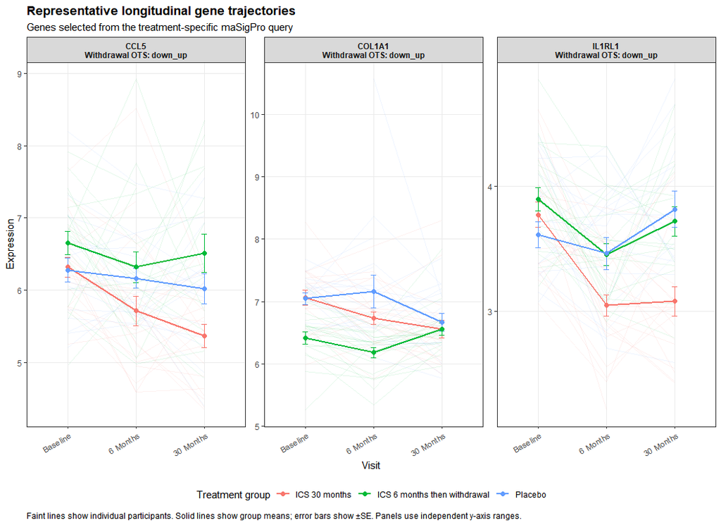

```r
p_gene_trajectories <- ggplot2::ggplot() +

  ggplot2::geom_line(
    data = expression_long,
    ggplot2::aes(
      x = visit,
      y = expression,
      group = interaction(
        group,
        subject_id
      ),
      colour = group
    ),
    alpha = 0.10,
    linewidth = 0.25,
    show.legend = FALSE
  ) +

  ggplot2::geom_errorbar(
    data = expression_summary,
    ggplot2::aes(
      x = visit,
      ymin = mean_expression - se_expression,
      ymax = mean_expression + se_expression,
      colour = group
    ),
    width = 0.08,
    linewidth = 0.45
  ) +

  ggplot2::geom_line(
    data = expression_summary,
    ggplot2::aes(
      x = visit,
      y = mean_expression,
      group = group,
      colour = group
    ),
    linewidth = 1
  ) +

  ggplot2::geom_point(
    data = expression_summary,
    ggplot2::aes(
      x = visit,
      y = mean_expression,
      colour = group
    ),
    size = 2.2
  ) +

  ggplot2::facet_wrap(
    ~ gene,
    scales = "free_y",
    ncol = 3,
    labeller = ggplot2::as_labeller(
      facet_labels
    )
  ) +

  ggplot2::labs(
    title = "Representative longitudinal gene trajectories",
    subtitle = "Genes selected from the treatment-specific maSigPro query",
    x = "Visit",
    y = "Expression",
    colour = "Treatment group",
    caption = paste0(
      "Faint lines show individual participants. ",
      "Solid lines show group means; error bars show ±SE. ",
      "Panels use independent y-axis ranges."
    )
  ) +

  ggplot2::theme_bw(base_size = 11) +

  ggplot2::theme(
    plot.title = ggplot2::element_text(
      face = "bold"
    ),
    strip.text = ggplot2::element_text(
      face = "bold"
    ),
    axis.text.x = ggplot2::element_text(
      angle = 30,
      hjust = 1
    ),
    plot.caption = ggplot2::element_text(
      hjust = 0
    ),
    panel.grid.minor = ggplot2::element_blank(),
    legend.position = "bottom"
  )

p_gene_trajectories
```

The gene-level profiles connect the discrete OTS labels to the observed expression data. For example, a gene labelled `down_up` decreases during the first interval and then increases during the second interval.

## Using your own data

The same workflow applies to another longitudinal dataset.

```r
expr_use <- your_expression_matrix
meta_use <- your_clinical_metadata

meta_use <- meta_use[
  match(
    colnames(expr_use),
    meta_use$sample_id
  ),
  ,
  drop = FALSE
]

rownames(meta_use) <- meta_use$sample_id

se <- SummarizedExperiment(
  assays = list(
    transcriptomics = expr_use
  ),
  colData = DataFrame(meta_use)
)

mae <- MultiAssayExperiment(
  experiments = ExperimentList(
    transcriptomics = se
  )
)

lot_object <- new(
  "LongOmicsTraj",
  mae = mae
)
```

The assay name may be changed to match the data, for example:

```r
assays = list(
  proteomics = protein_matrix
)
```

or:

```r
mae <- MultiAssayExperiment(
  experiments = ExperimentList(
    transcriptomics = transcriptomics_se,
    proteomics = proteomics_se,
    metabolomics = metabolomics_se
  )
)
```

## Summary

LongOmicsTraj starts from an expression matrix and clinical metadata. It estimates longitudinal profiles, computes adjacent changes and maps each feature to an interpretable trajectory signature. These signatures can then be compared across groups, queried using biological conditions and linked back to the observed molecular profiles.

## Quick reference

```r
# Load data
data("lot_glucold_expression")
data("lot_glucold_clinical")

# Create object
se <- SummarizedExperiment(
  assays = list(
    transcriptomics = lot_glucold_expression
  ),
  colData = DataFrame(
    lot_glucold_clinical
  )
)

mae <- MultiAssayExperiment(
  experiments = ExperimentList(
    transcriptomics = se
  )
)

lot <- new(
  "LongOmicsTraj",
  mae = mae
)

# Fit trajectories
lot <- lot_from_masigpro(
  lot,
  assay = "transcriptomics",
  visits = c(
    "Baseline",
    "6 Months",
    "30 Months"
  )
)

# Compute OTS
lot <- lot_compute_deltas(
  lot,
  assay = "transcriptomics",
  visits = c(
    "Baseline",
    "6 Months",
    "30 Months"
  )
)

lot <- lot_compute_thresholds(
  lot,
  assay = "transcriptomics",
  method = "hybrid",
  delta_min = 0.15,
  k = 0.5,
  visits = c(
    "Baseline",
    "6 Months",
    "30 Months"
  )
)

lot <- lot_map_to_ots(
  lot,
  visits = c(
    "Baseline",
    "6 Months",
    "30 Months"
  )
)

# Inspect results
head(
  as.data.frame(lot@ots)
)
```